# Building a phenomenological model of the human ear

### Computer Science PhD seminar

### Trevor Bekolay, Chris Eliasmith

# Goal

[figure not shown]

$\quad \Rightarrow \quad$

[figure not shown]

# The human ear

[figure not shown]

# In the Cochlea

[figure not shown]

$\quad$

[figure not shown]

# Modelling the auditory periphery

$$O(t) \Rightarrow S_{CF}(t)$$

### Naive approach: FFT

```python
rate = 100000
dt = 1. / rate

def tone(freq, ramp=0.025, t=0.25, rate=rate):
    x = np.linspace(0, t, rate * t)
    wave = np.sin(freq * x * 2 * np.pi) * 1.5
    # Ramp up and down
    ramp_size = int(rate * ramp)
    wave[:ramp_size] *= np.linspace(0, 1, ramp_size)
    wave[-ramp_size:] *= np.linspace(1, 0, ramp_size)
    return wave

def whitenoise(t=0.25, rate=rate):
    wn = brian.hears.whitenoise(t, samplerate=rate).ramp()
    return np.asarray(wn, dtype=np.float64).ravel()

def speech(rate=rate, path='speech.wav'):
    orig_rate, orig = readwav(path)
    new_size = orig.size * (rate / orig_rate)
    wave = scipy.signal.resample(orig, new_size)
    wave -= wave.mean()
    wave *= 0.048
    return wave
```

```
rms=0.987
```

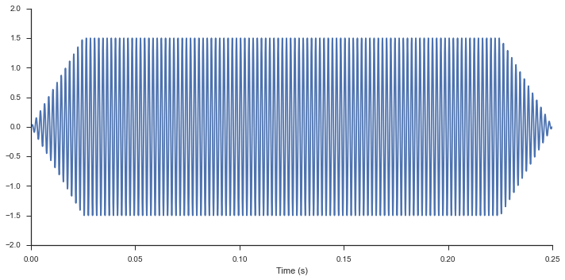

```python
tone_500 = tone(500)
print('rms=%.3f' % rms(tone_500))
plt.plot(np.arange(tone_500.size) * dt, tone_500)
plt.ylim(-2, 2)
plt.xlabel("Time (s)")
sns.despine()
plt.tight_layout()
```

```python
Audio(data=tone_500, rate=rate)
```

[interactive chart not shown]

```
rms=0.984
```

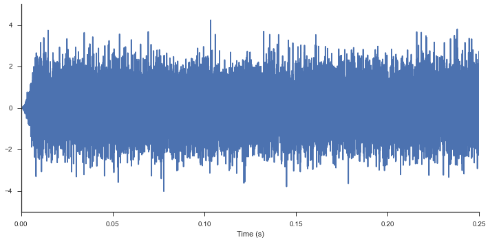

```python
noise = whitenoise()
print('rms=%.3f' % rms(noise))
plt.plot(np.arange(noise.size) * dt, noise)
plt.xlabel("Time (s)")
sns.despine()
plt.tight_layout()
```

```python
Audio(data=noise, rate=rate)
```

[interactive chart not shown]

```
rms=1.019
```

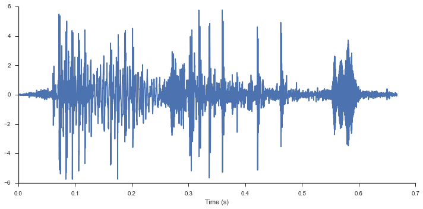

```python
human = speech()
print('rms=%.3f' % rms(human))
plt.plot(np.arange(human.size) * dt, human)
plt.xlabel("Time (s)")
sns.despine()
plt.tight_layout()
```

```python
Audio(data=human, rate=rate)
```

[interactive chart not shown]

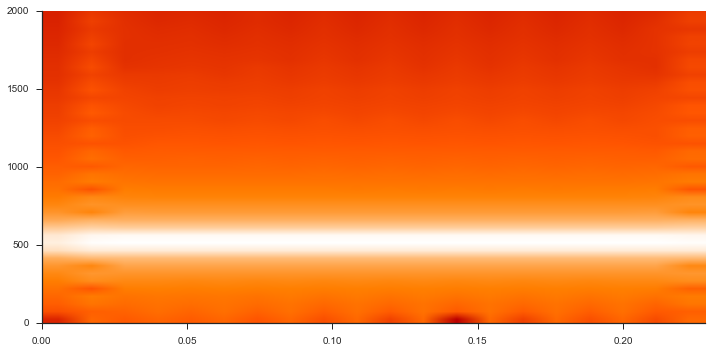

```python
plt.specgram(tone_500, NFFT=2048, Fs=rate, noverlap=900, cmap=plt.cm.gist_heat)
plt.axis('tight')
plt.ylim(top=2000)
sns.despine()
plt.tight_layout()
```

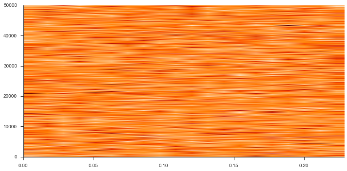

```python
plt.specgram(noise, NFFT=2048, Fs=rate, noverlap=900, cmap=plt.cm.gist_heat)
plt.axis('tight')
sns.despine()
plt.tight_layout()
```

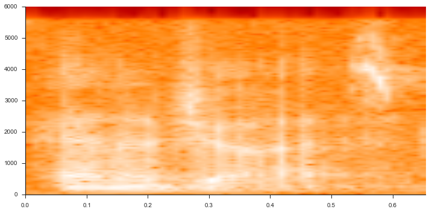

```python
plt.specgram(human, NFFT=2048, Fs=rate, noverlap=900, cmap=plt.cm.gist_heat)
plt.axis('tight')
plt.ylim(top=6000)
sns.despine()
plt.tight_layout()
```

# Nengo example

# Ear fact 1: logarithmic sensitivity

[figure not shown]

- [Bark scale](http://en.wikipedia.org/wiki/Bark_scale)
- [Mel scale](http://en.wikipedia.org/wiki/Mel_scale)
- [Equivalent Rectangular Bandwidth scale](https://en.wikipedia.org/wiki/Equivalent_rectangular_bandwidth)

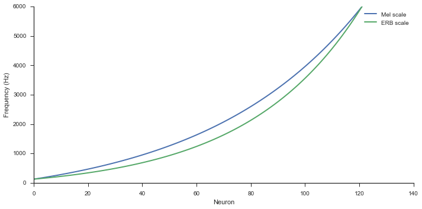

```python
mel_cf = melspace(125, 6000, n_freqs)
erb_cf = brian.hears.erbspace(125*brian.Hz, 6000*brian.Hz, n_freqs)

plt.plot(mel_cf, lw=2, label="Mel scale")
plt.plot(erb_cf, lw=2, label="ERB scale")
plt.ylabel("Frequency (Hz)")
plt.xlabel("Neuron")
plt.legend(loc='best')
sns.despine()
plt.tight_layout()
```

# Filter banks

[figure not shown]

# Psychoacoustic tuning curves

[figure not shown]

Zilany, Muhammad S.A., and Ian C. Bruce. Modeling auditory-nerve responses for high sound pressure levels in the normal and impaired auditory periphery. *The Journal of the Acoustical Society of America* 120.3 (2006): 1446-1466.

# Decent filter: Gammatone

Product of gamma distribution and sine wave.

[figure not shown]

- Left: [wikipedia](http://en.wikipedia.org/wiki/Gammatone_filter)
- Right: [Dan Ellis](http://www.ee.columbia.edu/ln/rosa/matlab/gammatonegram/)

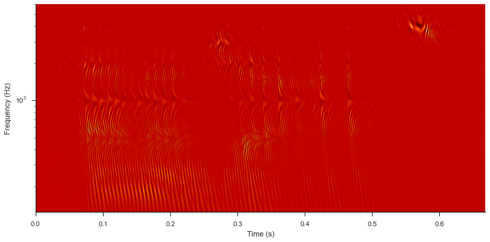

```python
sound = brian.hears.Sound(human, samplerate=rate * brian.Hz)
gammatone = brian.hears.Gammatone(sound, erb_cf)
gt_mon = gammatone.process()

xx, yy = np.meshgrid(sound.times, erb_cf)
plt.pcolormesh(xx, yy, gt_mon.T, cmap=plt.cm.gist_heat)
plt.axis('tight')
if True:
    plt.yscale('log')
plt.ylabel('Frequency (Hz)')
plt.xlabel('Time (s)')
sns.despine()
plt.tight_layout()
```

# Brian + Nengo example

# Ear facts 2 - ?: nonlinearities

# Ear fact 2: compressing nonlinearity

- If you double the input to the basilar membrane, the output less than doubles.

# Ear fact 3: suppressing nonlinearity

- If you add a second tone at a different frequency, the response to the first tone decreases

[figure not shown]

From [Chris Darwin](http://www.lifesci.sussex.ac.uk/home/Chris_Darwin/Perception/Lecture_Notes/Hearing2/hearing2.html)

# Cochlear amplifier

[figure not shown]

# Ear fact 4: peak splitting

- If you increase the amplitude past a certain point, the phase of the response can shift up to 180 degrees.

[figure not shown]

Kiang, Nelson Yuan-sheng. *Curious oddments of auditory-nerve studies.* Hearing research 49.1 (1990): 1-16.

# Zilany & Bruce phenomenological ear model

[figure not shown]

Zilany, Muhammad S.A., and Ian C. Bruce. Modeling auditory-nerve responses for high sound pressure levels in the normal and impaired auditory periphery. *The Journal of the Acoustical Society of America* 120.3 (2006): 1446-1466.

# Octave + Nengo example

# Summary

- The ear picks out frequency components in air pressure waves.
- Ear models are usually based on filter banks.
- Sophisticated models use nonlinear filters.

# Plans

- Hook up the Zilany & Bruce model to Nengo more cleanly.
- Listen to synthesized sounds.
- Learn to improve operational space control.